# Loading and preprocessing the data

## Loading and preprocessing the data

### Code to Load the data

- Directory was '/tmp/RepData_PeerAssessment1-master/'
- File was 'activity.csv'
- There was no transforming of the data at this time.

```r
setwd('/tmp/RepData_PeerAssessment1-master/')
data.file = 'activity.csv'
data.df = read.csv(file = data.file, header = TRUE)
```

### Histogram

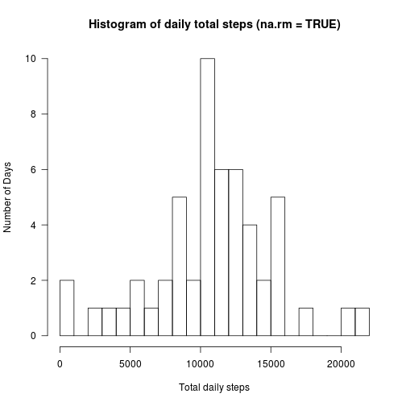

```r
dates.v = unique(data.df[["date"]])

totals.na.rm.v = c()

for (current.date in dates.v){
    current.data = subset(data.df, (date == current.date) & (!is.na(steps)))

    if (nrow(current.data) > 0){
        total.na.rm = sum(current.data[["steps"]], na.rm = TRUE)
        totals.na.rm.v = c(totals.na.rm.v, total.na.rm)
    }
}

breaks.v = seq(from = 0, to = 22000, by = 1000)

hist(totals.na.rm.v, breaks = breaks.v,
     main = "Histogram of daily total steps (na.rm = TRUE)",
     xlab = "Total daily steps",
     ylab = "Number of Days", las = 1)
```

## What is mean total number of steps taken per day?

```r
cat("Analysis of days, ignoring NA intervals\n",
    sprintf("%11i", length(dates.v)),
    " : 'raw' number of days in the data set\n",
    sprintf("%11i", length(totals.na.rm.v)),
    " : 'filtered' number of days (removed empty ",
    "days with no observations)\n",
    sprintf("%0.5f", mean(totals.na.rm.v)),
    " : (Filtered) Mean daily total\n",
    sprintf("%11i", median(totals.na.rm.v)),
    " : (Filtered) Median daily total\n", sep = '')
```

```
## Analysis of days, ignoring NA intervals
##          61 : 'raw' number of days in the data set
##          53 : 'filtered' number of days (removed empty days with no observations)
## 10766.18868 : (Filtered) Mean daily total
##       10765 : (Filtered) Median daily total
```

## What is the average daily activity pattern?

### Time series plot of the intervals and the average steps per interval

```r
library(hash)
```

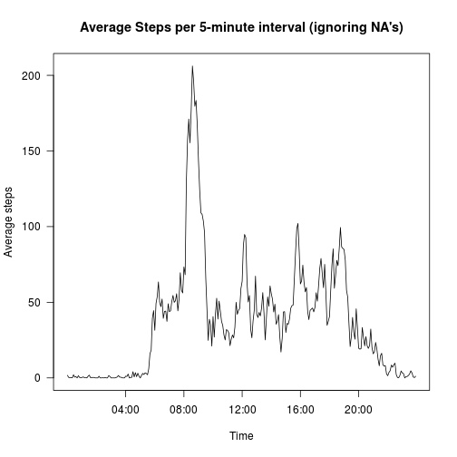

```r
convert.int__hh_mm = function(time.integer){
    if (time.integer < 100){
        time.string = paste("00:", time.integer, sep = '')
    } else {
        time.string = paste((time.integer %/% 100), ":",
            (time.integer %% 100), sep = "")
    }
    return(time.string)
}

intervals.v = unique(sort(data.df[["interval"]]))

daily.intervals.df = data.frame(interval.time.seconds = c(),
    average.steps = c())

row.counter = 0

max.average.steps = -1
argmax.interval   = NA

hash.interval.to.average = hash()

for (current.interval in intervals.v){
    row.counter = row.counter + 1
    current.df = subset(data.df,
        (interval == current.interval) & (!is.na(steps)))

    if (nrow(current.df) > 0){
        average.steps = mean(current.df[["steps"]])
    } else {
        average.steps = NA
    }

    hash.interval.to.average[[as.character(current.interval)]] = average.steps

    if (!is.na(average.steps)){
        if (average.steps > max.average.steps){
            max.average.steps = average.steps
            argmax.interval = current.interval
        }
    }

    time.string = convert.int__hh_mm(current.interval)

    ## if (current.interval < 100){
    ##    time.string = paste("00:", current.interval, sep = '')
    ## } else {
    ##    time.string = paste((current.interval %/% 100), ":",
    ##        (current.interval %% 100), sep = "")
    ## }

    daily.intervals.df[row.counter, "interval.time.seconds"] =
        as.integer(as.POSIXct(paste("1970-01-01", time.string, sep = ''),
                              "%Y-%m-%d %H:%M"))

    daily.intervals.df[row.counter, "average.steps"] = average.steps

}



x.axis.tick.times = c("04:00", "08:00", "12:00", "16:00", "20:00")

x.axis.tick.seconds = as.vector(sapply(x.axis.tick.times,
    function(time.string){
        as.integer(as.POSIXct(paste("1970-01-01", time.string, sep = ''),
                              "%Y-%m-%d %H:%M"))}))

plot(x = daily.intervals.df[["interval.time.seconds"]],
     y = daily.intervals.df[["average.steps"]],
     type = "l", las = 1, xlab = "Time", ylab = "Average steps",
     main = "Average Steps per 5-minute interval (ignoring NA's)",
     xaxt = "n")

axis(1, at = x.axis.tick.seconds, labels = x.axis.tick.times)
```

### Which 5-minute intervals has the highest average number of steps?

```r
argmax.interval.time.string = NA

if (!is.na(argmax.interval)){
    argmax.interval.time.string = convert.int__hh_mm(argmax.interval)
}

if (max.average.steps == -1){
    max.average.steps.string = "      NA"
} else {
    max.average.steps.string = sprintf("%3.4f", max.average.steps)
}

cat(sprintf("%10s", argmax.interval.time.string),
    " -- interval with the maximum average number of steps\n",
    sprintf("%10s", max.average.steps.string),
    " -- average number of steps in that interval\n", sep = '')
```

```
##       8:35 -- interval with the maximum average number of steps
##   206.1698 -- average number of steps in that interval
```

## Imputing missing values

### Total number of missing values

```r
cat(sum(is.na(data.df[["steps"]])), " : number of intervals with missing",
    " data (namely the interval has NA for # of steps)\n", sep = '')
```

```
## 2304 : number of intervals with missing data (namely the interval has NA for # of steps)
```

### Strategy for imputing missing values, and creating the new dataset.

- We took the simplistic approach that if an interval was missing, we would use the rounded average value of that interval across all the days (as we computed before, omitting NA's)

Code to impute missing values!

```r
round.5 = function(value){
    return(trunc(value + 0.5))
}


imputed.data.df = data.df


for (row.index in c(1:nrow(data.df))){
    if (is.na(imputed.data.df[row.index, "steps"])){
        current.interval = data.df[row.index, "interval"]
        imputed.data.df[row.index, "steps"] =
            round.5(hash.interval.to.average[[as.character(current.interval)]])
    }
}
```

### Histogram (with imputed values!)

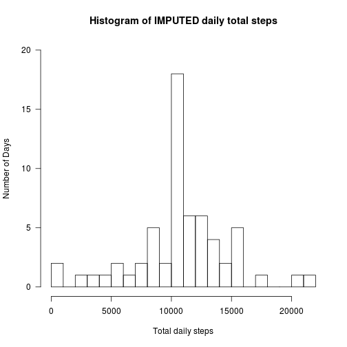

```r
imputed.totals.v = c()

for (current.date in dates.v){
    ## Actually, since we imputed data, we don't need to do the !is.na
    ## condition, but I include it for completeness.
    current.data = subset(imputed.data.df,
        (date == current.date) & (!is.na(steps)))

    if (nrow(current.data) > 0){
        imputed.total    = sum(current.data[["steps"]], na.rm = TRUE)
        imputed.totals.v = c(imputed.totals.v, imputed.total)
    }
}

breaks.v = seq(from = 0, to = 22000, by = 1000)

hist(imputed.totals.v, breaks = breaks.v,
     main = "Histogram of IMPUTED daily total steps",
     xlab = "Total daily steps",
     ylab = "Number of Days", ylim = c(0, 20), las = 1)
```

Now we report the mean and median per day, with the imputed values.

```r
cat(sprintf("%0.5f", mean(imputed.totals.v)),
    " : (Imputed) Mean daily total\n",
    sprintf("%11i", median(imputed.totals.v)),
    " : (Imputed) Median daily total\n", sep = '')
```

```
## 10765.63934 : (Imputed) Mean daily total
##       10762 : (Imputed) Median daily total
```

Comparing with the previous values (ignoring the NA's, and not imputing values), we see that the difference is rather minimal, precisely because we imputed the rounded averages of non-NA values to the NA values. (The values are slightly different, because we rounded the average to the nearest integer).

The daily totals obviously increased; in fact our data had no 'orphan' missing NA's. (Namely all NA's were together in various days; if one interval in a day was missing, *every* interval in that day was missing).

Hence the histogram of daily totals had a marked increase at the mean daily total (which was about 10766 in this data).

## Are there differences in activity patterns between weekdays and weekends?

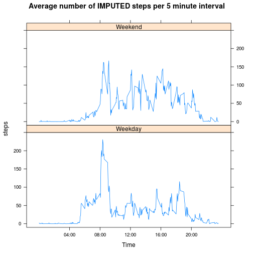

```r
library(lattice)
day.of.week.v = weekdays(as.Date(imputed.data.df[["date"]]))

imputed.data.df[["weekday.indicator"]] = as.vector(sapply(day.of.week.v,
                   function(day.of.week){
                       if (day.of.week %in% c("Saturday", "Sunday")){
                           return("Weekend")
                       } else {
                           return("Weekday")}}))

imputed.data.df[["weekday.indicator"]] =
    as.factor(imputed.data.df[["weekday.indicator"]])



xyplot(steps ~ interval|weekday.indicator, data = imputed.data.df,
       type = c('a'), layout = c(1,2), ylim = c(-10,250),
       xlab = 'Time',
       main = "Average number of IMPUTED steps per 5 minute interval",
       scales = list(x = list(
                         at = c(400,800,1200,1600,2000),
                         labels = c("04:00", "08:00", "12:00",
                             "16:00", "20:00"))))
```

As we can see, there are rather marked differences in the exercise pattern, between weekdays and weekends. For example, there is a marked peak around 8 am during the weekdays (due to a commute schedule?) that is not quite as dramatic during the weekends.